# Communicate_Data_Findings_Prosper_Loans slides

## Investigating Prosper Loans Datasets

### Reading and Exploring Dataset

```python
df = pd.read_csv('prosperLoanData.csv')
df.head()
```

|  | ListingKey | ListingNumber | ListingCreationDate | CreditGrade | Term | LoanStatus | ClosedDate | BorrowerAPR | BorrowerRate | LenderYield | ... | LP_ServiceFees | LP_CollectionFees | LP_GrossPrincipalLoss | LP_NetPrincipalLoss | LP_NonPrincipalRecoverypayments | PercentFunded | Recommendations | InvestmentFromFriendsCount | InvestmentFromFriendsAmount | Investors |
| --- | --- | --- | --- | --- | --- | --- | --- | --- | --- | --- | --- | --- | --- | --- | --- | --- | --- | --- | --- | --- | --- |
| 0 | 1021339766868145413AB3B | 193129 | 2007-08-26 19:09:29.263000000 | C | 36 | Completed | 2009-08-14 00:00:00 | 0.16516 | 0.1580 | 0.1380 | ... | -133.18 | 0.0 | 0.0 | 0.0 | 0.0 | 1.0 | 0 | 0 | 0.0 | 258 |
| 1 | 10273602499503308B223C1 | 1209647 | 2014-02-27 08:28:07.900000000 | NaN | 36 | Current | NaN | 0.12016 | 0.0920 | 0.0820 | ... | 0.00 | 0.0 | 0.0 | 0.0 | 0.0 | 1.0 | 0 | 0 | 0.0 | 1 |
| 2 | 0EE9337825851032864889A | 81716 | 2007-01-05 15:00:47.090000000 | HR | 36 | Completed | 2009-12-17 00:00:00 | 0.28269 | 0.2750 | 0.2400 | ... | -24.20 | 0.0 | 0.0 | 0.0 | 0.0 | 1.0 | 0 | 0 | 0.0 | 41 |
| 3 | 0EF5356002482715299901A | 658116 | 2012-10-22 11:02:35.010000000 | NaN | 36 | Current | NaN | 0.12528 | 0.0974 | 0.0874 | ... | -108.01 | 0.0 | 0.0 | 0.0 | 0.0 | 1.0 | 0 | 0 | 0.0 | 158 |
| 4 | 0F023589499656230C5E3E2 | 909464 | 2013-09-14 18:38:39.097000000 | NaN | 36 | Current | NaN | 0.24614 | 0.2085 | 0.1985 | ... | -60.27 | 0.0 | 0.0 | 0.0 | 0.0 | 1.0 | 0 | 0 | 0.0 | 20 |

5 rows × 81 columns

```python
df.info()
```

```
<class 'pandas.core.frame.DataFrame'>
RangeIndex: 113937 entries, 0 to 113936
Data columns (total 81 columns):
ListingKey                             113937 non-null object
ListingNumber                          113937 non-null int64
ListingCreationDate                    113937 non-null object
CreditGrade                            28953 non-null object
Term                                   113937 non-null int64
LoanStatus                             113937 non-null object
ClosedDate                             55089 non-null object
BorrowerAPR                            113912 non-null float64
BorrowerRate                           113937 non-null float64
LenderYield                            113937 non-null float64
EstimatedEffectiveYield                84853 non-null float64
EstimatedLoss                          84853 non-null float64
EstimatedReturn                        84853 non-null float64
ProsperRating (numeric)                84853 non-null float64
ProsperRating (Alpha)                  84853 non-null object
ProsperScore                           84853 non-null float64
ListingCategory (numeric)              113937 non-null int64
BorrowerState                          108422 non-null object
Occupation                             110349 non-null object
EmploymentStatus                       111682 non-null object
EmploymentStatusDuration               106312 non-null float64
IsBorrowerHomeowner                    113937 non-null bool
CurrentlyInGroup                       113937 non-null bool
GroupKey                               13341 non-null object
DateCreditPulled                       113937 non-null object
CreditScoreRangeLower                  113346 non-null float64
CreditScoreRangeUpper                  113346 non-null float64
FirstRecordedCreditLine                113240 non-null object
CurrentCreditLines                     106333 non-null float64
OpenCreditLines                        106333 non-null float64
TotalCreditLinespast7years             113240 non-null float64
OpenRevolvingAccounts                  113937 non-null int64
OpenRevolvingMonthlyPayment            113937 non-null float64
InquiriesLast6Months                   113240 non-null float64
TotalInquiries                         112778 non-null float64
CurrentDelinquencies                   113240 non-null float64
AmountDelinquent                       106315 non-null float64
```

[output cut: 31 more lines]

```
LP_CustomerPayments                    113937 non-null float64
LP_CustomerPrincipalPayments           113937 non-null float64
LP_InterestandFees                     113937 non-null float64
LP_ServiceFees                         113937 non-null float64
LP_CollectionFees                      113937 non-null float64
LP_GrossPrincipalLoss                  113937 non-null float64
LP_NetPrincipalLoss                    113937 non-null float64
LP_NonPrincipalRecoverypayments        113937 non-null float64
PercentFunded                          113937 non-null float64
Recommendations                        113937 non-null int64
InvestmentFromFriendsCount             113937 non-null int64
InvestmentFromFriendsAmount            113937 non-null float64
Investors                              113937 non-null int64
dtypes: bool(3), float64(50), int64(11), object(17)
memory usage: 68.1+ MB
```

```python
df.describe()
```

|  | ListingNumber | Term | BorrowerAPR | BorrowerRate | LenderYield | EstimatedEffectiveYield | EstimatedLoss | EstimatedReturn | ProsperRating (numeric) | ProsperScore | ... | LP_ServiceFees | LP_CollectionFees | LP_GrossPrincipalLoss | LP_NetPrincipalLoss | LP_NonPrincipalRecoverypayments | PercentFunded | Recommendations | InvestmentFromFriendsCount | InvestmentFromFriendsAmount | Investors |
| --- | --- | --- | --- | --- | --- | --- | --- | --- | --- | --- | --- | --- | --- | --- | --- | --- | --- | --- | --- | --- | --- |
| count | 1.139370e+05 | 113937.000000 | 113912.000000 | 113937.000000 | 113937.000000 | 84853.000000 | 84853.000000 | 84853.000000 | 84853.000000 | 84853.000000 | ... | 113937.000000 | 113937.000000 | 113937.000000 | 113937.000000 | 113937.000000 | 113937.000000 | 113937.000000 | 113937.000000 | 113937.000000 | 113937.000000 |
| mean | 6.278857e+05 | 40.830248 | 0.218828 | 0.192764 | 0.182701 | 0.168661 | 0.080306 | 0.096068 | 4.072243 | 5.950067 | ... | -54.725641 | -14.242698 | 700.446342 | 681.420499 | 25.142686 | 0.998584 | 0.048027 | 0.023460 | 16.550751 | 80.475228 |
| std | 3.280762e+05 | 10.436212 | 0.080364 | 0.074818 | 0.074516 | 0.068467 | 0.046764 | 0.030403 | 1.673227 | 2.376501 | ... | 60.675425 | 109.232758 | 2388.513831 | 2357.167068 | 275.657937 | 0.017919 | 0.332353 | 0.232412 | 294.545422 | 103.239020 |
| min | 4.000000e+00 | 12.000000 | 0.006530 | 0.000000 | -0.010000 | -0.182700 | 0.004900 | -0.182700 | 1.000000 | 1.000000 | ... | -664.870000 | -9274.750000 | -94.200000 | -954.550000 | 0.000000 | 0.700000 | 0.000000 | 0.000000 | 0.000000 | 1.000000 |
| 25% | 4.009190e+05 | 36.000000 | 0.156290 | 0.134000 | 0.124200 | 0.115670 | 0.042400 | 0.074080 | 3.000000 | 4.000000 | ... | -73.180000 | 0.000000 | 0.000000 | 0.000000 | 0.000000 | 1.000000 | 0.000000 | 0.000000 | 0.000000 | 2.000000 |
| 50% | 6.005540e+05 | 36.000000 | 0.209760 | 0.184000 | 0.173000 | 0.161500 | 0.072400 | 0.091700 | 4.000000 | 6.000000 | ... | -34.440000 | 0.000000 | 0.000000 | 0.000000 | 0.000000 | 1.000000 | 0.000000 | 0.000000 | 0.000000 | 44.000000 |
| 75% | 8.926340e+05 | 36.000000 | 0.283810 | 0.250000 | 0.240000 | 0.224300 | 0.112000 | 0.116600 | 5.000000 | 8.000000 | ... | -13.920000 | 0.000000 | 0.000000 | 0.000000 | 0.000000 | 1.000000 | 0.000000 | 0.000000 | 0.000000 | 115.000000 |
| max | 1.255725e+06 | 60.000000 | 0.512290 | 0.497500 | 0.492500 | 0.319900 | 0.366000 | 0.283700 | 7.000000 | 11.000000 | ... | 32.060000 | 0.000000 | 25000.000000 | 25000.000000 | 21117.900000 | 1.012500 | 39.000000 | 33.000000 | 25000.000000 | 1189.000000 |

8 rows × 61 columns

### Data Preparation

```python
#converting dates into datetime objects
df.ListingCreationDate = pd.to_datetime(df.ListingCreationDate)
df.LoanOriginationDate = pd.to_datetime(df.LoanOriginationDate)
df.ClosedDate = pd.to_datetime(df.ClosedDate)
```

```python
df.IncomeRange.unique()
df.IncomeRange[df.IncomeRange == '$25,000-49,999'] = 'Below 50K'
df.IncomeRange[df.IncomeRange == '$50,000-74,999'] = 'Below 75K'
df.IncomeRange[df.IncomeRange == '$75,000-99,999'] = 'Below 100K'
df.IncomeRange[df.IncomeRange == '$1-24,999'] = 'Below 25K'
df.IncomeRange[df.IncomeRange == '$100,000+'] = 'Above 100K'
df.IncomeRange[df.IncomeRange == '$0'] = 'No Income'
```

```python
df.LoanStatus [(df.LoanStatus == 'Past Due (1-15 days)' ) | (df.LoanStatus == 'Past Due (16-30 days)') | (df.LoanStatus == 'Past Due (31-60 days)' )] = 'past Due (<60 days)'
df.LoanStatus [(df.LoanStatus == 'Past Due (61-90 days)' ) | (df.LoanStatus == 'Past Due (91-120 days)')  ] = 'past Due (<120 days)'
```

### Univariate Exploration

### What is the loan status of the majority of borrowers?

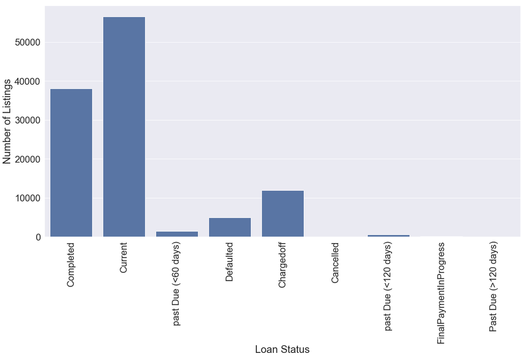

```python
plt.figure(figsize=(20,10))
sns.countplot(x="LoanStatus", data=df , color = sns.color_palette()[0]);
plt.xlabel('Loan Status')
plt.ylabel('Number of Listings')
sns.set(font_scale=2)
plt.xticks(rotation=90);
```

> the above chart shows that the loan status of the majority of loans is 'running loans' or 'completed'

### What is the income range of the majority of borrowers at the time the listings created?

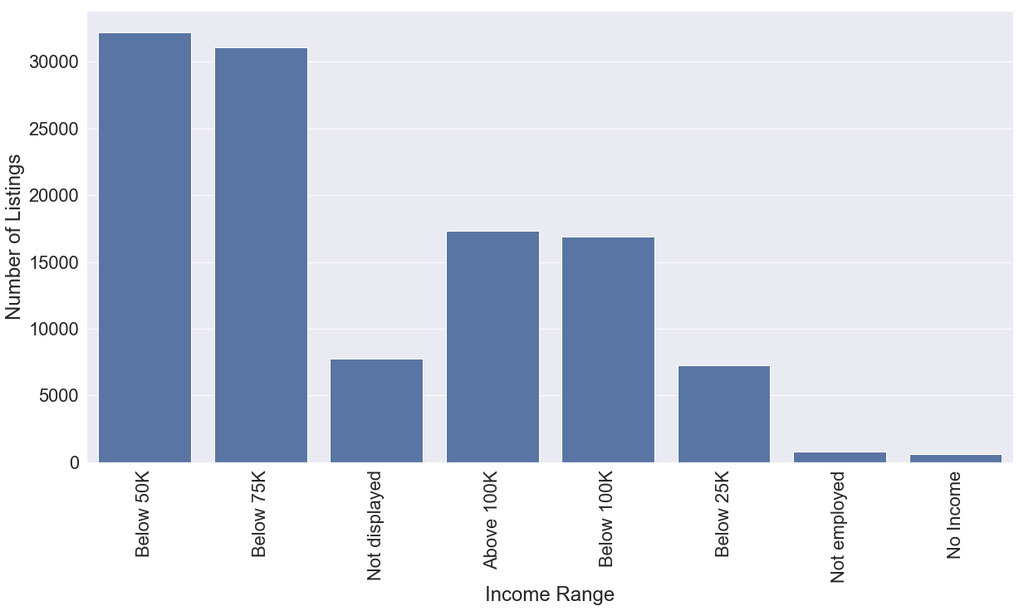

```python
plt.figure(figsize=(20,10))
sns.countplot(x="IncomeRange", data=df , color = sns.color_palette()[0]);
plt.xlabel('Income Range')
plt.ylabel('Number of Listings')
#sns.set(font_scale=2)
plt.xticks(rotation=90);
```

```python
df['IncomeVerifiable'].value_counts(normalize = True)
```

```
True     0.923914
False    0.076086
Name: IncomeVerifiable, dtype: float64
```

> The income range of borrowers shows that the majority of borrowers' income is less than 75,000$, and around 92 percent provided the documents that supported and verfied their income

### What is the debt to income ratio of the majority of listings ?

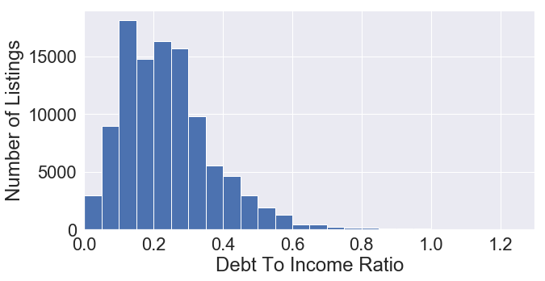

```python
#univariate plot of debt income ratio on a standard scale
plt.figure(figsize=[10, 5])
binsize = 0.05
bins = np.arange(0, df ['DebtToIncomeRatio'].max()+binsize, binsize)
plt.hist(data = df, x = 'DebtToIncomeRatio', bins = bins)
plt.xlim([0, 1.3])
plt.xlabel('Debt To Income Ratio')
plt.ylabel('Number of Listings')
plt.show()
```

> Debt to income ratio for the majority of listings was less than 0.4, which means that the maximum debt amount that most of borrowers had obtianed was less than 30,000$

### What is the interest rate of the majority of listings ?

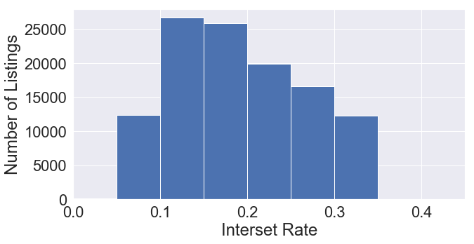

```python
#univariate plot of borrower rate on a standard scale
plt.figure(figsize=[10, 5])
binsize = 0.05
bins = np.arange(0, df ['BorrowerRate'].max()+binsize, binsize)
plt.hist(data = df, x = 'BorrowerRate', bins = bins)
plt.xlim([0, 0.45])
plt.xlabel('Interset Rate')
plt.ylabel('Number of Listings')
plt.show()
```

### Bivariate Exploration

> I would like to investigate the correlation between some continous variables using the heatmap

```python
numeric_var = ['BorrowerRate' , 'LoanOriginalAmount' , 'DebtToIncomeRatio' , 'Recommendations' , 'StatedMonthlyIncome' , 'Investors']
```

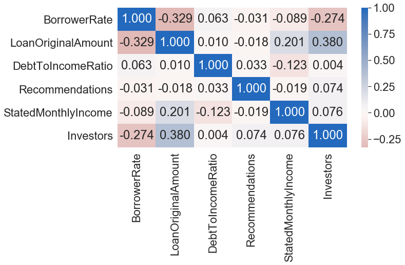

```python
plt.figure(figsize = [10, 5])
sns.heatmap(df[numeric_var].corr(), annot = True, fmt = '.3f',
           cmap = 'vlag_r', center = 0)
plt.show()
```

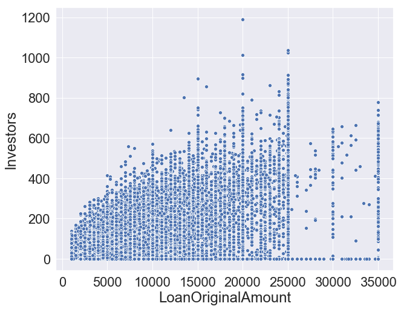

```python
plt.figure(figsize = [10, 8])

sns.scatterplot(data=df, x="LoanOriginalAmount", y="Investors" );
```

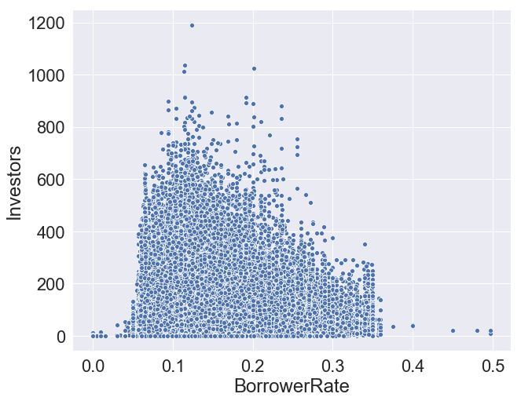

```python
plt.figure(figsize = [10, 8])

sns.scatterplot(data=df, x="BorrowerRate", y="Investors" );
```

> the heatmap and scatter plots demonstrates that the loan amount is positively correlated the most with the borrower's monthly income and the number of investors that funded the loan, while it is negatively correlated with the interest rate. Hence, the interst rate is also negatively correlated with the number of investors that funded the loan.

### What is the debt to income ratio and interest rate of borrowers according to the loan status ?

```python
df.LoanStatus [(df.LoanStatus == 'Past Due (1-15 days)' ) | (df.LoanStatus == 'Past Due (16-30 days)') | (df.LoanStatus == 'Past Due (31-60 days)' )] = 'past Due (<60 days)'
df.LoanStatus [(df.LoanStatus == 'Past Due (61-90 days)' ) | (df.LoanStatus == 'Past Due (91-120 days)')  ] = 'past Due (<120 days)'
```

```python
df.LoanStatus.value_counts()
```

```
Current                   56576
Completed                 38074
Chargedoff                11992
Defaulted                  5018
past Due (<60 days)        1434
past Due (<120 days)        617
FinalPaymentInProgress      205
Past Due (>120 days)         16
Cancelled                     5
Name: LoanStatus, dtype: int64
```

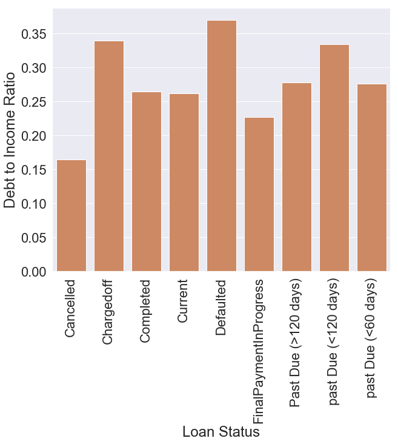

```python
plt.figure(figsize=[10, 8])
LoanStatus_incomeratio = df.groupby ("LoanStatus")['DebtToIncomeRatio'].agg(["mean"])
LoanStatus_incomeratio = LoanStatus_incomeratio.reset_index()
sns.barplot(x="LoanStatus", y="mean", data=LoanStatus_incomeratio , color = sns.color_palette()[1]);
plt.xlabel('Loan Status')
plt.ylabel('Debt to Income Ratio')
plt.xticks(rotation=90);
```

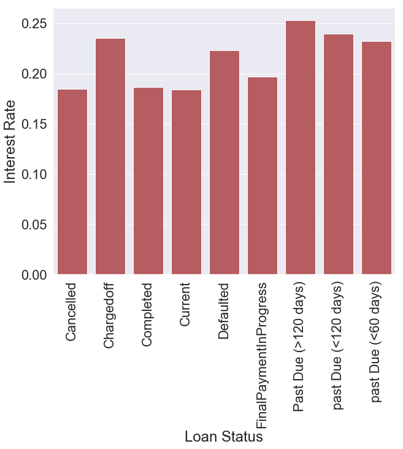

```python
plt.figure(figsize=[10, 8])
LoanStatus_borrowerrate = df.groupby ("LoanStatus")['BorrowerRate'].agg(["mean"])
LoanStatus_borrowerrate = LoanStatus_borrowerrate.reset_index()
sns.barplot(x="LoanStatus", y="mean", data=LoanStatus_borrowerrate , color = sns.color_palette()[3]);
plt.xlabel('Loan Status')
plt.ylabel('Interest Rate')
plt.xticks(rotation=90);
```

> the above to bar charts show that the debt to income ratio and interest rate for borrowers with loan status (Defaulted) or (Charged off) was higher than others completed their loans

### Multivariate Exploration

```python
# plt.figure(figsize=[10, ])
df_sub = df[['LoanStatus' , 'IncomeRange' , 'DebtToIncomeRatio' , 'BorrowerRate']]
df_sub_agg = df_sub.groupby(['LoanStatus' , 'IncomeRange'])['DebtToIncomeRatio'].agg(['mean'])
df_sub_agg = df_sub_agg.reset_index()
df_sub_agg
```

|  | LoanStatus | IncomeRange | mean |
| --- | --- | --- | --- |
| 0 | Cancelled | Below 50K | 0.340000 |
| 1 | Cancelled | Not displayed | 0.121085 |
| 2 | Chargedoff | Above 100K | 0.188400 |
| 3 | Chargedoff | Below 100K | 0.215828 |
| 4 | Chargedoff | Below 25K | 0.921717 |
| 5 | Chargedoff | Below 50K | 0.270021 |
| 6 | Chargedoff | Below 75K | 0.237795 |
| 7 | Chargedoff | No Income | NaN |
| 8 | Chargedoff | Not displayed | 0.337974 |
| 9 | Chargedoff | Not employed | 4.725455 |
| 10 | Completed | Above 100K | 0.159530 |
| 11 | Completed | Below 100K | 0.186699 |
| 12 | Completed | Below 25K | 0.713701 |
| 13 | Completed | Below 50K | 0.253460 |
| 14 | Completed | Below 75K | 0.217409 |
| 15 | Completed | No Income | NaN |
| 16 | Completed | Not displayed | 0.286306 |
| 17 | Completed | Not employed | 2.542857 |
| 18 | Current | Above 100K | 0.188221 |
| 19 | Current | Below 100K | 0.225710 |
| 20 | Current | Below 25K | 0.564421 |
| 21 | Current | Below 50K | 0.295107 |
| 22 | Current | Below 75K | 0.259980 |
| 23 | Current | No Income | NaN |
| 24 | Current | Not employed | NaN |
| 25 | Defaulted | Above 100K | 0.210565 |
| 26 | Defaulted | Below 100K | 0.241967 |
| 27 | Defaulted | Below 25K | 1.446645 |
| 28 | Defaulted | Below 50K | 0.317796 |
| 29 | Defaulted | Below 75K | 0.283041 |
| 30 | Defaulted | No Income | NaN |
| 31 | Defaulted | Not displayed | 0.293631 |
| 32 | Defaulted | Not employed | 4.434286 |
| 33 | FinalPaymentInProgress | Above 100K | 0.176809 |
| 34 | FinalPaymentInProgress | Below 100K | 0.189600 |
| 35 | FinalPaymentInProgress | Below 25K | 0.301000 |
| 36 | FinalPaymentInProgress | Below 50K | 0.281333 |
| 37 | FinalPaymentInProgress | Below 75K | 0.229032 |
| 38 | Past Due (>120 days) | Below 100K | 0.030000 |
| 39 | Past Due (>120 days) | Below 50K | 0.338571 |
| 40 | Past Due (>120 days) | Below 75K | 0.248333 |
| 41 | Past Due (>120 days) | No Income | NaN |
| 42 | past Due (<120 days) | Above 100K | 0.191864 |
| 43 | past Due (<120 days) | Below 100K | 0.203067 |
| 44 | past Due (<120 days) | Below 25K | 1.216591 |
| 45 | past Due (<120 days) | Below 50K | 0.319798 |
| 46 | past Due (<120 days) | Below 75K | 0.232386 |
| 47 | past Due (<120 days) | No Income | NaN |
| 48 | past Due (<120 days) | Not employed | NaN |
| 49 | past Due (<60 days) | Above 100K | 0.187385 |
| 50 | past Due (<60 days) | Below 100K | 0.219387 |
| 51 | past Due (<60 days) | Below 25K | 0.615281 |
| 52 | past Due (<60 days) | Below 50K | 0.299833 |
| 53 | past Due (<60 days) | Below 75K | 0.252147 |
| 54 | past Due (<60 days) | No Income | NaN |
| 55 | past Due (<60 days) | Not employed | NaN |

[figure not shown]

```python
plt.figure(figsize=[15, 10])
sns.barplot(x="LoanStatus", y="mean", data=df_sub_agg ,  hue= "IncomeRange" , color = sns.color_palette()[3]);
plt.legend(loc='upper right')
plt.xlabel('Loan Status')
plt.ylabel('Interest Rate')
plt.xticks(rotation=90);
```